# One Line Plot - Bar Chart

Walter Xie

16/02/2017

```r
library(gg1L)
#getwd()
```

## Bar chart

Load the example data *model.test*, select “Mac” only in *OS* column, and display the first 3 rows:

```r
data(model.test)
model.test.mac <- model.test[model.test$OS=="Mac",]
model.test.mac[1:3,]
```

```
##   model test performance  OS
## 1   GTR 1044    1.144838 Mac
## 2   GTR 1366    1.081676 Mac
## 3   GTR 1510    1.078596 Mac
```

Plot the performance score of each test in four GTR models, where the texts of x-axis were rotated, and also use `verbose=F` to block messages:

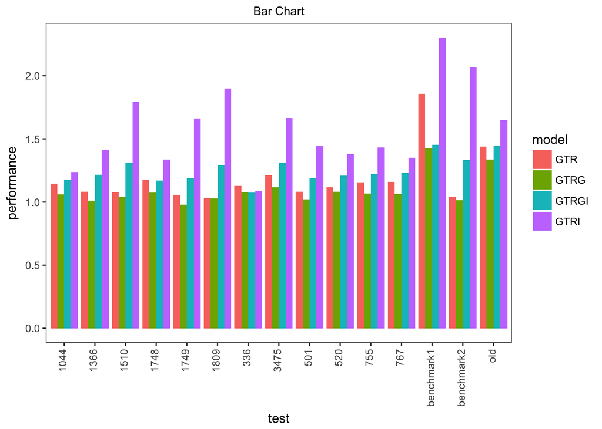

```r
ggBarChart(model.test.mac, x.id="test", y.id="performance", fill.id="model", x.text.angle=90, verbose=F)
```

### Adjust position of bars

Change the plot to stack bar chart using `bar.pos=“stack”`, and title to “Stack Bar Chart”:

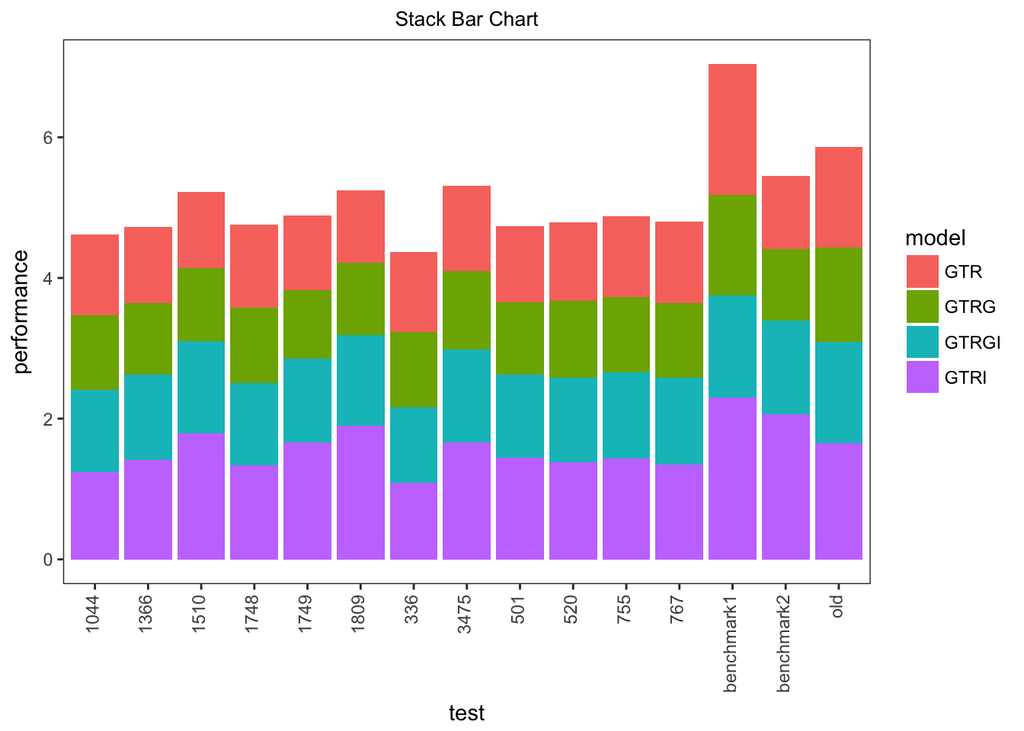

```r
ggBarChart(model.test.mac, x.id="test", y.id="performance", fill.id="model", x.text.angle=90,
           bar.pos="stack", title="Stack Bar Chart", verbose=F)
```

Use both `bar.pos=“fill”` and `y.trans=“per”` to create a typical percentage bar chart:

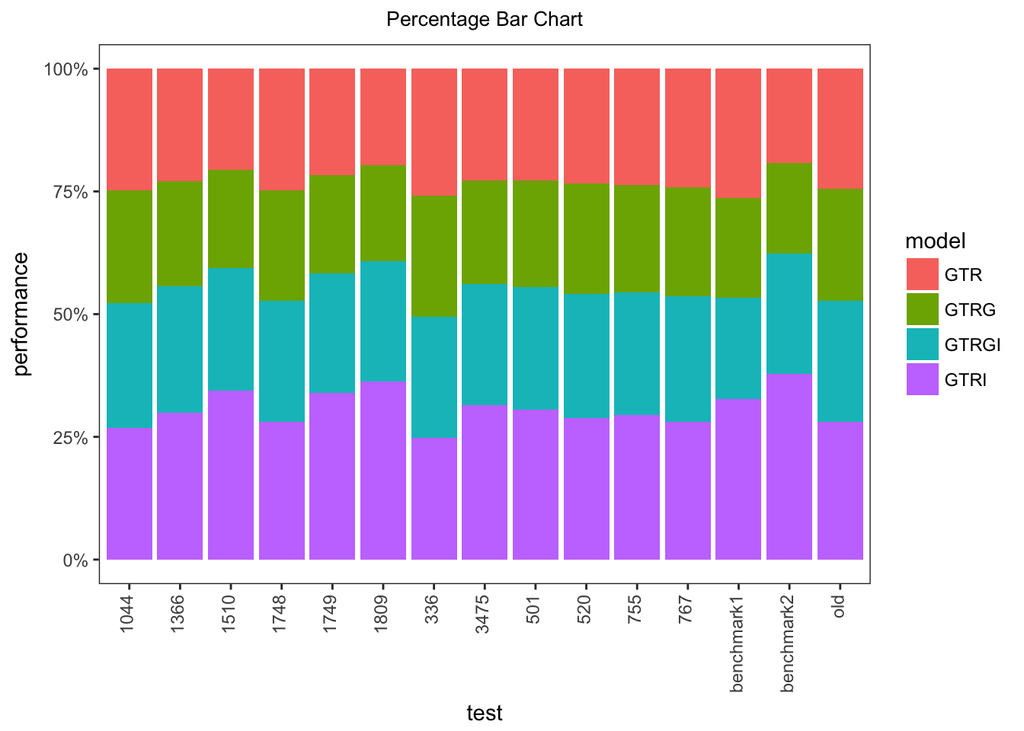

```r
ggBarChart(model.test.mac, x.id="test", y.id="performance", fill.id="model", x.text.angle=90,
           bar.pos="fill", y.trans="per", title="Percentage Bar Chart", verbose=F)
```

## Add something to bars

### Add error bars

using `aggregate` modified from [the code] (http://www.r-bloggers.com/building-barplots-with-error-bars/) in R Bloggers:

```r
myData <- aggregate(model.test$performance, by=list(model=model.test$model,OS=model.test$OS),
                    FUN=function(x) c(mean=mean(x), sd=sd(x), n=length(x)))
myData <- do.call(data.frame, myData)
myData$se <- myData$x.sd / sqrt(myData$x.n)
colnames(myData) <- c("model", "OS", "performance", "sd", "n", "se")
myData[1:3,]
```

```
##   model    OS performance        sd  n         se
## 1   GTR Linux    1.157008 0.2867760 15 0.07404525
## 2  GTRG Linux    1.084187 0.1367728 15 0.03531458
## 3 GTRGI Linux    1.393784 0.6169104 15 0.15928558
```

Or use `summarySE` in this package which is copied from [Cookbook for R](http://www.cookbook-r.com/Manipulating_data/Summarizing_data/):

```r
myData <- summarySE(model.test, measurevar="performance", groupvars=c("model", "OS"))
myData[1:3,]
```

```
##   model      OS  N performance        sd         se        ci
## 1   GTR   Linux 15    1.157008 0.2867760 0.07404525 0.1588113
## 2   GTR     Mac 15    1.184172 0.2100471 0.05423394 0.1163202
## 3   GTR Windows 15    1.176700 0.2283331 0.05895536 0.1264467
```

Add the error bars to the bar chart using `+`, where *performance* column is the mean:

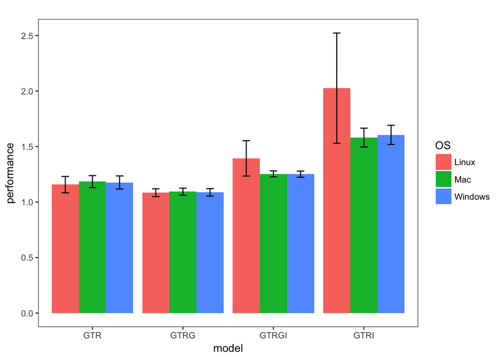

```r
bc <- ggBarChart(myData, x.id="model", y.id="performance", fill.id="OS", y.lab="performance", title="", verbose=F)
bc + ggAddErrorBars(lower="performance-se", upper="performance+se", verbose=F)
```

### Add values

Add their values (in the column “n”) to the bars:

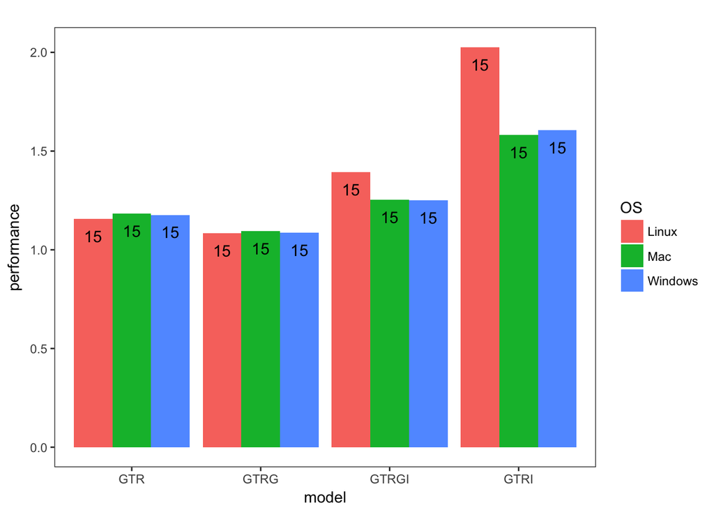

```r
bc + ggAddNumbers(label.id="N", hjust=0.5, vjust=2)
```

Add the calculation result to the bars, such as the mean of y values:

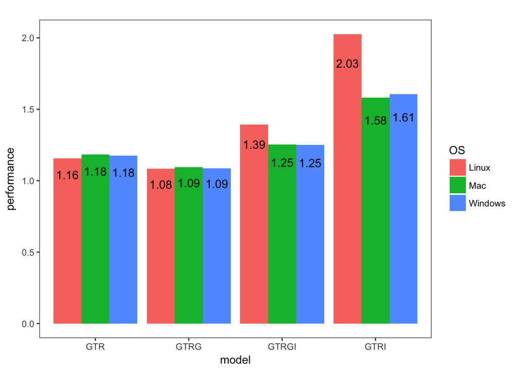

```r
bc + ggAddNumbersFun(fun.y.lab=mean, y.adj=0.9)
```

### Add lines

Add the red line to show `y=1`:

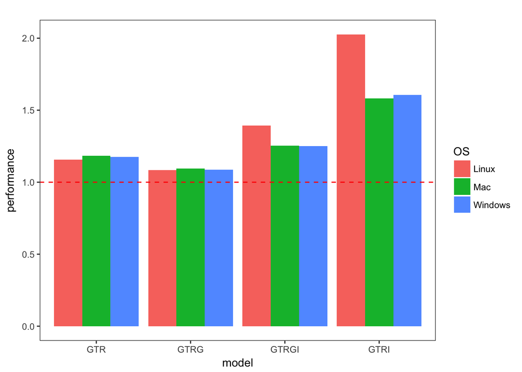

```r
bc + ggAddLine(linetype = 2, yintercept = 1, color="red")
```

## More Types

Load the example data *reads.phyla*, where *x* is one of genetic marks, and the numbers are eDNA sequences (reads) identified as the phylum listed in *y*:

```r
data(reads.phyla)
reads.phyla[1:2,]
```

```
##                16S 18S trnL ITS COI COI-spun TaxaGroup
## Actinobacteria 958   1  301   4   7        0  Bacteria
## Aquificae        0   0   10   0   0        0  Bacteria
```

### Percentage bar

This is a brief version of percentage bar, which uses `melt.id=“TaxaGroup”` to specify the column of groups:

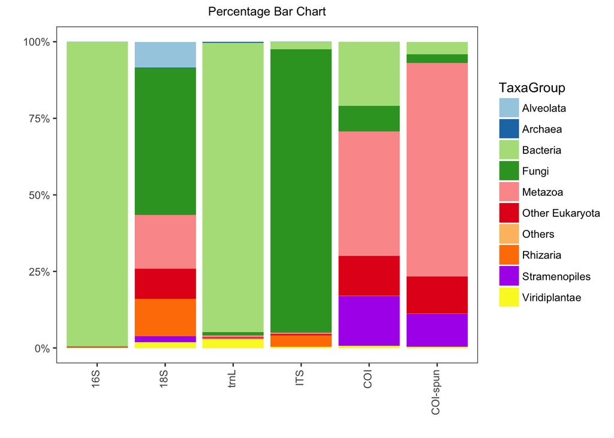

```r
pbc <- ggPercentageBarChart(reads.phyla, melt.id="TaxaGroup", verbose=F)
pbc$gg.plot
```

### Abundance bar by group

Use `melt.id=“phylum”` to determine the value of bars (the numbers of reads of each phylum), but to group data and colour the bars by “TaxaGroup”. Use *width* and *height* in `pdf` to resize the plot. It can also use the estimated width and height from the function.

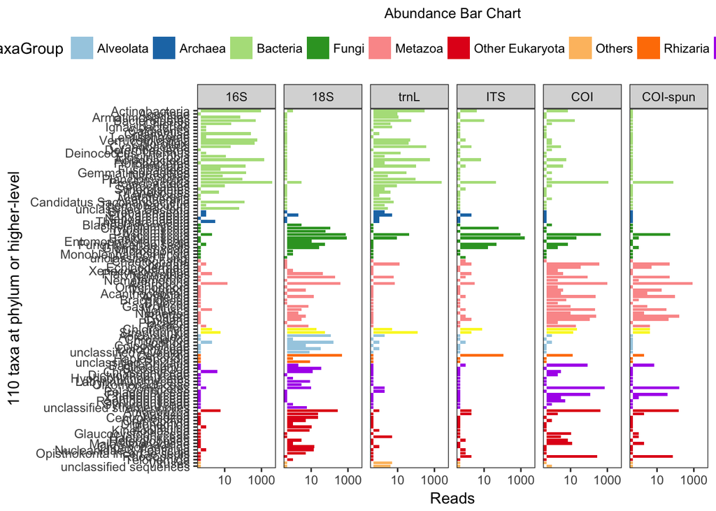

```r
# add melt.id
reads.phyla$phylum <- rownames(reads.phyla)
ab <- ggGroupAbundanceBar(reads.phyla, melt.id="phylum", colour.id="TaxaGroup", legend.row=1, verbose=F)
ab$gg.plot
```

```r
#pdf.ggplot(ab$gg.plot, fig.path="abundance-bar.pdf", width=ab$pdf.width, height=ab$pdf.height)
```

### Y across X bar chart

This bar chart introduced in the supplymentary data of https://doi.org/10.1186/s13742-015-0086-1 shows both of the total value of *y* (the number of reads) and the frequency of *y* (the number of phyla) appeared and only appeared in the given number of columns (datasets) listed in x-axis.

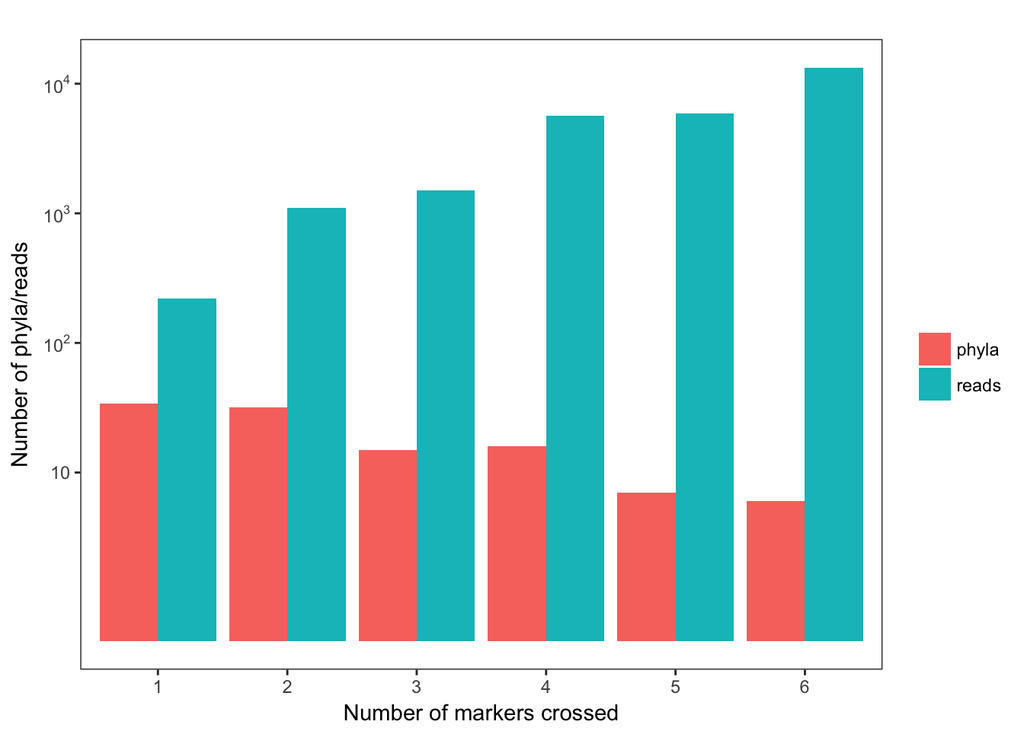

```r
ggYAcrossXBar(reads.phyla[,1:6], terms=c("phyla", "datasets", "reads"), title="",
              x.lab="Number of markers crossed", y.lab="Number of phyla/reads", verbose=F)
```